# STA141A Final Project: Predicting the Feedback Type of a Mice Performing a Visual Discrimination Task

Anna Si

2024-03-05

# Abstract

The objective of this report is to create a model to predict the feedback response using data from the Steinmetz’s (2019) experiment on organization of neurons in the mice brain corresponding to a visual choice task. I reached this objective by analyzing the unique structure of this dataset that was split into sessions and trials. Using dimension reduction techniques through PCA and creating a model based off the results from our exploratory analysis, I concluded that the most influential predictors on feedback response was the region spike rate, contrast difference, contrast left, contrast right, session id, and trial id. The final model using ROC curves allowed me to determine an AUC value of 84%.

# Section 1: Introduction

There are multiple factors that contribute to a behavior in a mice. By defining what constitutes neuronal activity, we can use data from the brain to predict behavior such as in this experiment where the mice was given a visual discrimination task. This can expanded upon in the future of the research industry such as in neural networks. The model aims to predict a mice’s ability to successfully determine if the right or left side has a smaller contrast level based on the eight variables: contrast_left, contrast_right, mouse_name, brain_area, date_exp, spks, and time.

# Section2: Exploratory Analysis

Across all sessions, there are eight variables: contrast_left, contrast_right, feedback_type, mouse_name, brain_area, date_exp, spks, and time. Each session has one of four mice under mouse_name. In each trial we are given contrast levels between the right and left side, the number of spikes, the time it took for the mice to respond, and the brain areas that were activated in the trial. The feedback type is whether the mice succeeds or fails at determining which has a smaller contrast. The date that the experiment took place should have no influence if the trial conditions were randomly selected.

### Description of Variables for Each Trial

- feedback_type: 1 for success and -1 for failure, where if left_contrast > right_contrast = success if mice turns the wheel right and if left_contrast < right_contrast = success if mice turns the wheel to the left (turn whichever side has a higher contrast). Failure otherwise.
- contrast_left and contrast_right: the contrast level of the respective side taking values with range {0.0,0.25,0.5,0.75,1}
- time: time in seconds from when the visual stimulus is revealed to mice
- brain_area: the brain areas that house the neurons that were activated in the trial
- spks: number of spikes for a neuron in the visual cortex
- date_exp: the date of the trial was performed; this variable doesn’t look influential unless there was some form of learning going on with the mice and trials

| Mouse Name | Experiment Date | Amount of Brain Areas | Number of Neurons | Number of Trials | Success Rate |
| --- | --- | --- | --- | --- | --- |
| Cori | 2016-12-14 | 8 | 734 | 114 | 0.61 |
| Cori | 2016-12-17 | 5 | 1070 | 251 | 0.63 |
| Cori | 2016-12-18 | 11 | 619 | 228 | 0.66 |
| Forssmann | 2017-11-01 | 11 | 1769 | 249 | 0.67 |
| Forssmann | 2017-11-02 | 10 | 1077 | 254 | 0.66 |
| Forssmann | 2017-11-04 | 5 | 1169 | 290 | 0.74 |
| Forssmann | 2017-11-05 | 8 | 584 | 252 | 0.67 |
| Hench | 2017-06-15 | 15 | 1157 | 250 | 0.64 |
| Hench | 2017-06-16 | 12 | 788 | 372 | 0.69 |
| Hench | 2017-06-17 | 13 | 1172 | 447 | 0.62 |
| Hench | 2017-06-18 | 6 | 857 | 342 | 0.80 |
| Lederberg | 2017-12-05 | 12 | 698 | 340 | 0.74 |
| Lederberg | 2017-12-06 | 15 | 983 | 300 | 0.80 |
| Lederberg | 2017-12-07 | 10 | 756 | 268 | 0.69 |
| Lederberg | 2017-12-08 | 8 | 743 | 404 | 0.76 |
| Lederberg | 2017-12-09 | 6 | 474 | 280 | 0.72 |
| Lederberg | 2017-12-10 | 6 | 565 | 224 | 0.83 |
| Lederberg | 2017-12-11 | 10 | 1090 | 216 | 0.81 |

### Observing changes across sessions

To start the exploratory data analysis, I created a table to summarize the information across sessions from the data. Then, I considered both of the TA’s data processing techniques introduced in “Project Demo 2” since I found both neural activities reasonable in predicting feedback types. Research suggests that it may be that the spike pattern across the time bins, rather than average spike rate across trials, can indicate a successful trial (Reference 1). Thus, spatiotemporal patterns across trials might be an influential in model building for predicting behavior.

The first data processing technique defined neuronal activity as the mean spike rate per brain area. Once grouping trials and sessions by the brain_areas, I created a data frame with number of brain areas, total spikes in a brain area, and the mean spike rate in a brain region. The second data processing technique, is helpful when observing spatiotemporal patterns and defines neuronal activity as the spike rate for each time bin and creates a data frame with the spike rate for each of the 40 time bins. Both data frames also have variables contrast levels for the side, contrast difference, session id, trial id, name, and date.

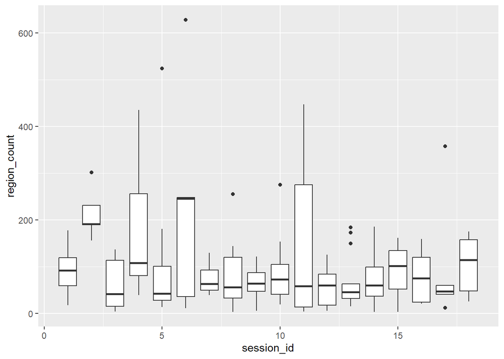

Furthermore, the number of neurons measured across sessions vary greatly, with session 4 having a major outlier at 1700 neurons (Appendix Figure 1). To further explore the heterogeneity, the data above shows that across sessions, the mean number of unique brain areas activated is nearly the same. As explained above, there are certain sessions with extreme outliers such as session 6. In addition, all of the sessions have larger variance differences for the region count showing that there is no consistency which would negatively impact the ability of my model to predict the feedback type. To combat this, both data processing techniques averaged the spike rate across all neurons in a trial. This prevents the specific number of neurons to cause issues in model building and allows us to create a single model to predict all trials. Although, it may be more accurate to create two models for session 1 and session 18 for our test data, ignoring the remaining sessions for training would lead to increased inaccuracies.

I will use both data processing methods in the exploratory data analysis to see which one would be more predictive before delving into data integration.

Furthermore, aside from neuron number changing across sessions, we can also see variables such as date, contrast levels, and success rate vary. Each session occurs at a different dates with varying contrast levels for right and left. Looking at the table above, the number of unique brain areas differs across sessions, although there are no outliers in the data. It appears that there is no relation between unique brain areas and success rate, since sessions with greater success rates do not necessarily have more unique brain areas. For instance, in session 17 there are only 6 brain areas with an 83% success, while session 16 also has 6 brain areas and 72% success, which may indicate that the number unique brain areas activated is not influential in predicting success rate. However, it may be that while the number of unique brain areas activated is not influential, but specific brain areas that are activated influence whether the behavior is a success.

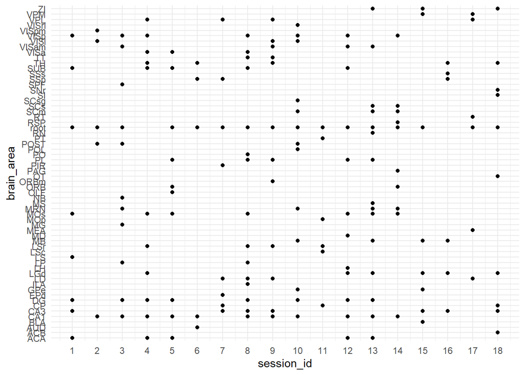

Based off the plot, aside from the root and CA1 brain areas, the locations activated are variable for each session. There is no pattern across sessions. Later in the report, I will analyze the brain areas activated in a successful trial, to see if it would be beneficial to use data processing method 1 to get region mean spike rate.

```
## # A tibble: 4 × 2
##   mouse_name success_rate
##   <chr>             <dbl>
## 1 Cori              0.639
## 2 Forssmann         0.687
## 3 Hench             0.684
## 4 Lederberg         0.761
```

Looking at the success rates across mice, there seems to be a natural variability in the rates of performing the behavior. It seems like Cori is least successful while Lederberg is more successful at performing the task. This could be because there were more sessions, and thus more trials, that recorded Lederberg, but it may also be that there are inherent differences in the mice’s willingness or ability to perform the behavior. I noted that this may lead to problems when creating a model to predict session 1 and session 18 since they come from different mice.

### Observing differences across trials

**The number of unique brain areas across trials:**

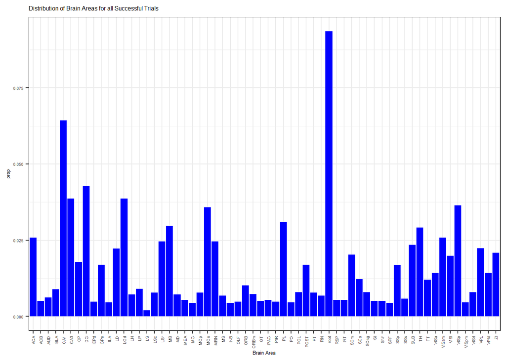

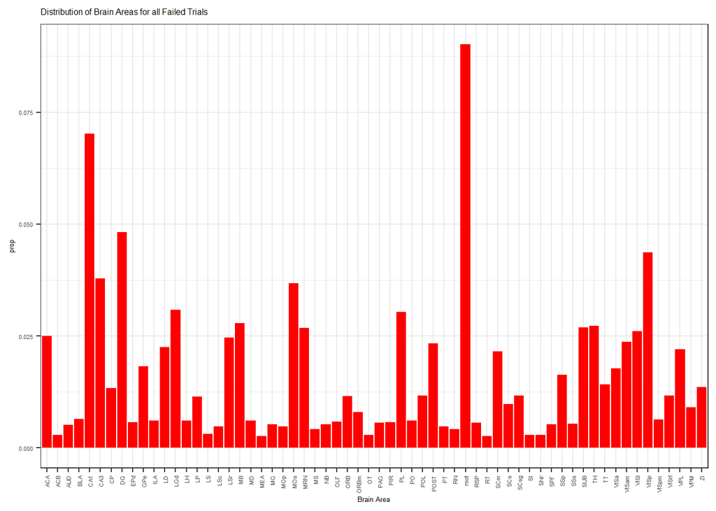

Since the proportion of activated unique brain areas is nearly identical in both success vs failure trials, which may indicate that brain area is not a good predictor since it is nearly identical in both feedback types. Aside from very small brain areas switching in relative proportions, the pattern is identical across failed and successful trials,and that unique brain areas are not influential on success.

**The spike rate of a given brain area within a trial:**

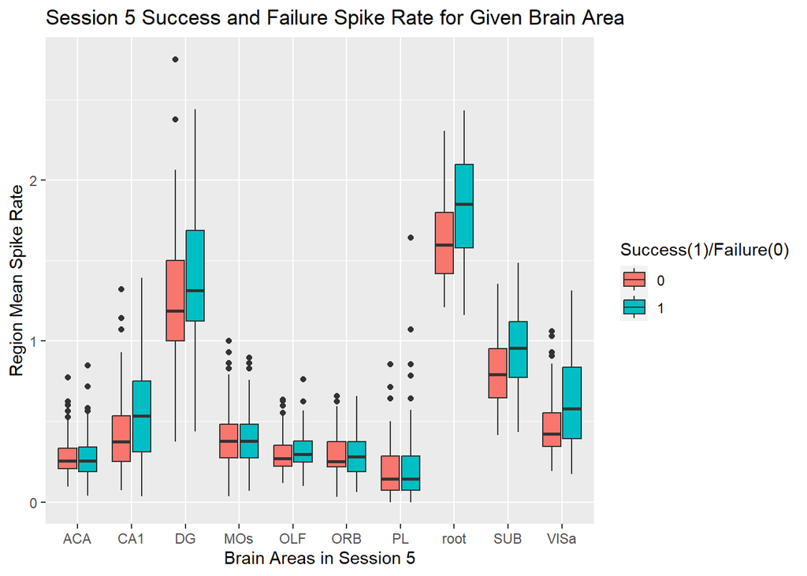

To analyze if there was any relation between feedback type and spike rate in a given area, I did a bar graph of a random session to look at the trials. It appears that mean spike rates in the brain regions DG, CA1, root, SUB, and VISa are higher in successful trials than in failure trials. Thus, this shows that increased neural activity of these brain regions, as defined as region mean spike rate, will result in a successful trial. However, since the failure mean spike rate for all of those brain areas overlap with the third quartiles of the success boxplots, I am not fully confident that this difference is significant. It appears that spike rate in a given brain area could be a potential predictor of feedback type and it might be beneficial to include this in the final model.

**Contrast difference for each feedback type**

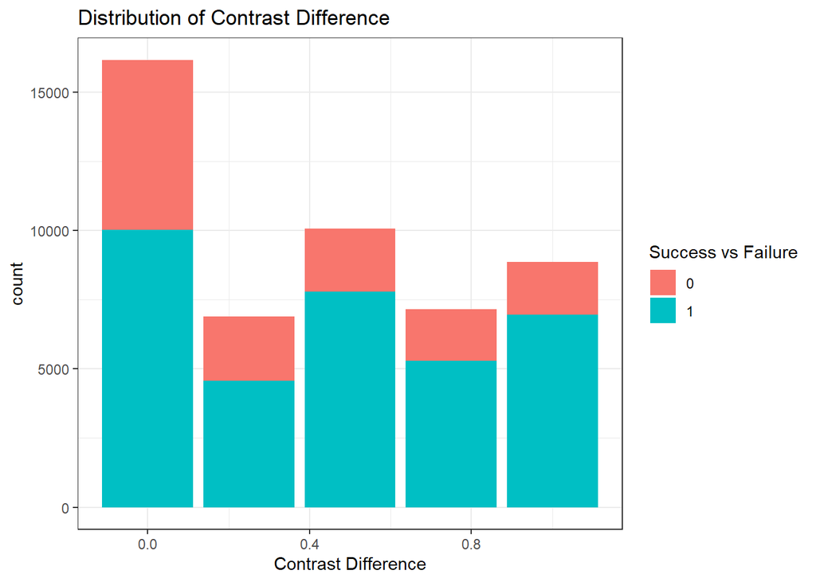

```
##            contrast_diff
## mouse_name           0       0.25        0.5       0.75          1
##   Cori      0.36256324 0.08768971 0.20236088 0.13153457 0.21585160
##   Forssmann 0.36555024 0.20095694 0.19425837 0.13301435 0.10622010
##   Hench     0.28773919 0.13465627 0.21190645 0.13182140 0.23387668
##   Lederberg 0.33612205 0.13090551 0.20816929 0.16584646 0.15895669
```

Based off the bar graph, the contrast difference distribution is not equal. 30% of the data is with a contrast difference of 0 while only 14% for differences of 0.25 and 0.75. This may indicate that success rate is dependent on the different distributions of contrast difference. Looking at the table showing contrast distributions for each mice, even though Cori has a similar distribution to Hench, their success rates are not close, 0.63 and 0.68 respectively.

**The spike rate across time:**

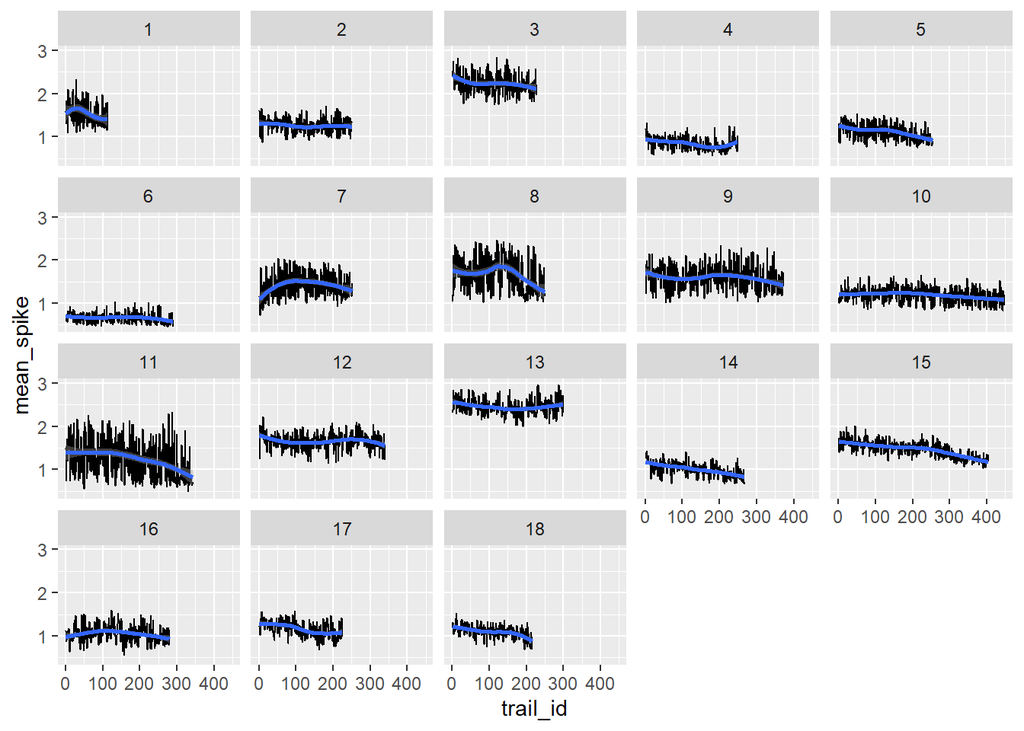

**The success rate over time:**

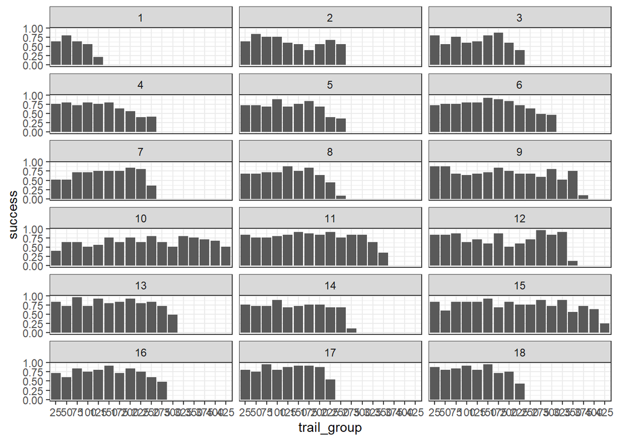

Overall, I found that the first data processing method where I grouped on brain areas and the mean spike rate per region as the most valuable one to use. It seems that increased spike rates in certain areas could potentially be a predictor, along with contrast difference, trial id, and session id. Since I already included the region_mean_spike, including the region_sum_spike seems repetitive. The number of unique brain areas and the spike rate per time bin doesn’t seem to follow a general pattern, so I decided to not include it in the report.

### Dimension Reduction and Feature Selection

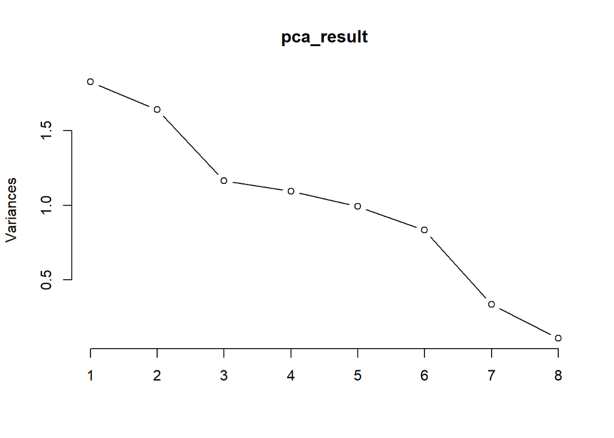

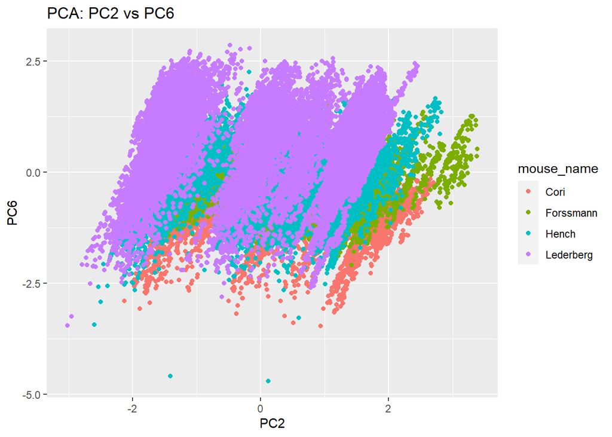

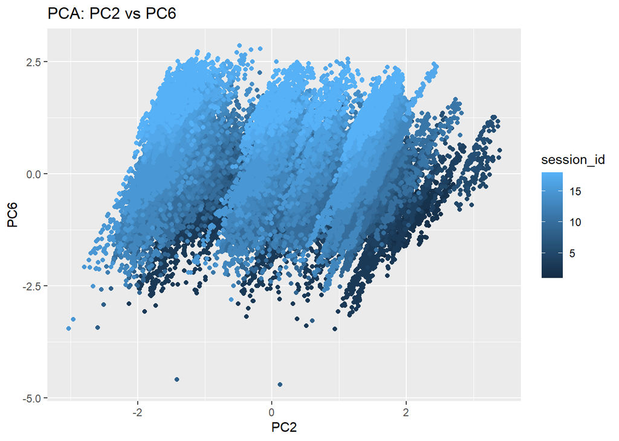

# Section 3: Data Integration

```
## # A tibble: 6 × 6
##   region_mean_spike trail_id session_id contrast_right contrast_left
##               <dbl>    <int>      <int>          <dbl>         <dbl>
## 1             1.27         1          1            0.5             0
## 2             1.53         1          1            0.5             0
## 3             2.32         1          1            0.5             0
## 4             1.94         1          1            0.5             0
## 5             0.938        1          1            0.5             0
## 6             2.08         1          1            0.5             0
## # ℹ 1 more variable: contrast_diff <dbl>
```

# Section 4: Predictive modeling

### Training 80% of the trials from all sessions

```
## [1] 0.7893024
```

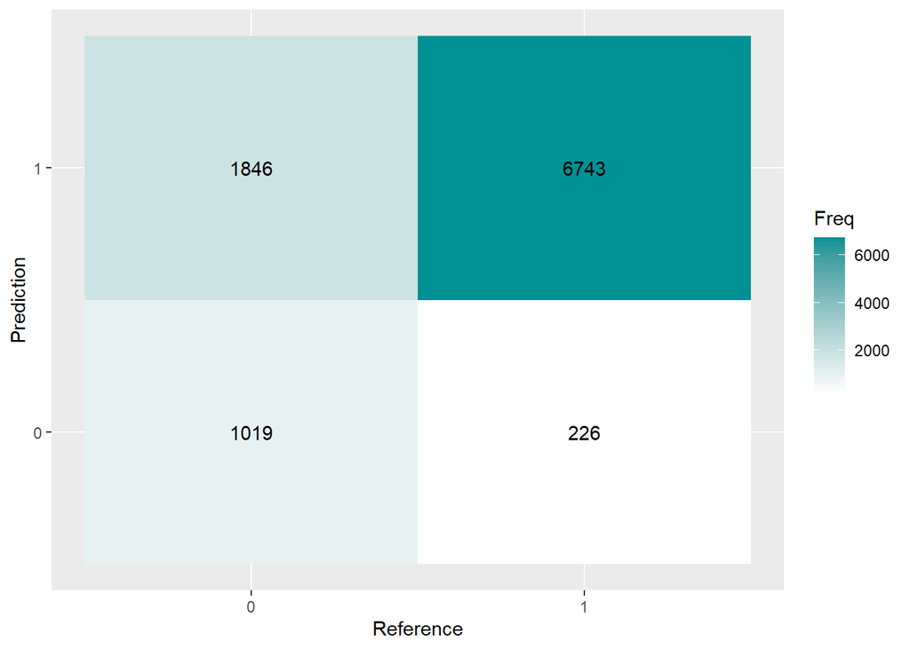

Based off the xgboost model confusion matrix I found that number of false positives is 1846 and false negatives is 226. Thus this model predicts more successful trials and it has a good performance predicting successful trials at 6743.

**Logistic regression model for binary outcome** To try a different approach I did a logistic regression model using the same variables from my XG Boost model to see if that would yield more accurate results.

```
##
## Call:
## glm(formula = success ~ ., family = "binomial", data = train_df_log)
##
## Coefficients:
##                     Estimate Std. Error z value Pr(>|z|)
## (Intercept)        0.4420902  0.0362277  12.203   <2e-16 ***
## region_mean_spike  0.0946070  0.0102283   9.250   <2e-16 ***
## trail_id          -0.0034614  0.0001173 -29.501   <2e-16 ***
## session_id         0.0565635  0.0026710  21.177   <2e-16 ***
## contrast_right    -0.5379807  0.0347782 -15.469   <2e-16 ***
## contrast_left     -0.2814527  0.0341119  -8.251   <2e-16 ***
## contrast_diff      1.3603586  0.0411344  33.071   <2e-16 ***
## ---
## Signif. codes:  0 '***' 0.001 '**' 0.01 '*' 0.05 '.' 0.1 ' ' 1
##
## (Dispersion parameter for binomial family taken to be 1)
##
##     Null deviance: 47833  on 39338  degrees of freedom
## Residual deviance: 45409  on 39332  degrees of freedom
## AIC: 45423
##
## Number of Fisher Scoring iterations: 4
```

```
## The prediction error is 0.2959121
```

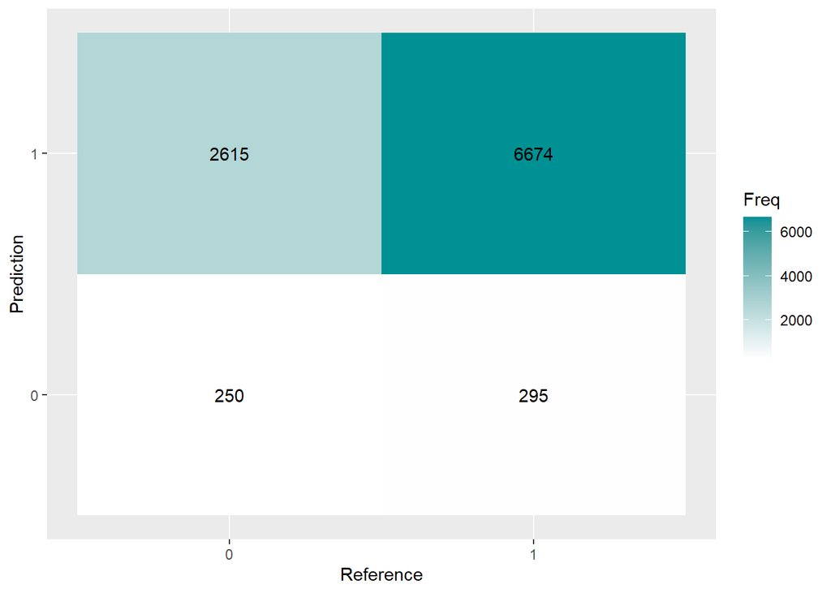

### ROC curves

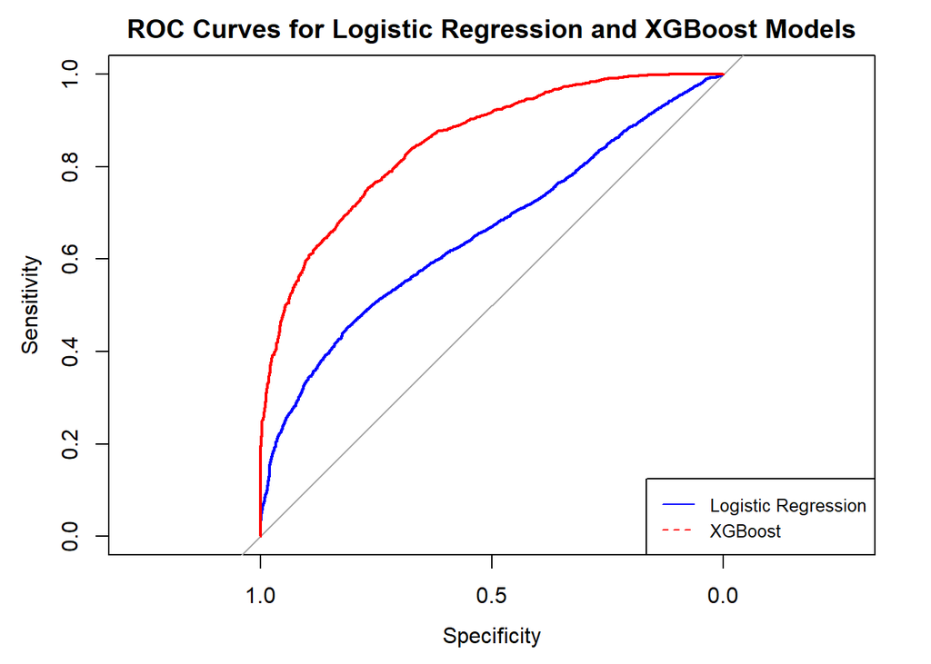

```
## The AUC for the logistic regression model is 0.6556711
```

```
## The AUC for the XG Boost model is 0.8476
```

# Section 5: Prediction performance on the test sets

## Model’s performance on test data of session 1

```
## The accuracy of the data is 0.76125
```

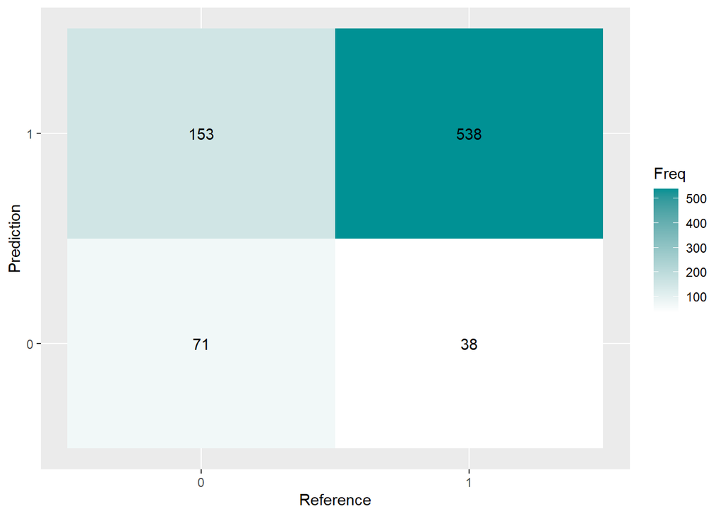

```
##
## Call:
## roc.default(response = label1, predictor = predictions1)
##
## Data: predictions1 in 224 controls (label1 0) < 576 cases (label1 1).
## Area under the curve: 0.6903
```

```
## The accuracy of the data is 0.69
```

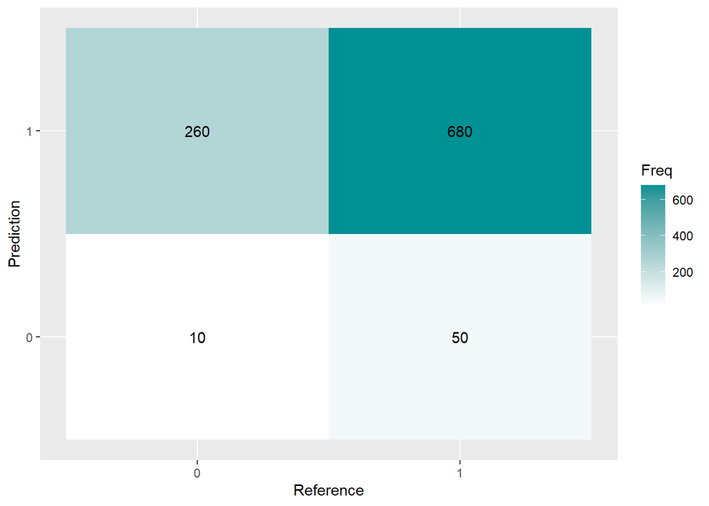

```
##
## Call:
## roc.default(response = label18, predictor = predictions18)
##
## Data: predictions18 in 270 controls (label18 0) < 730 cases (label18 1).
## Area under the curve: 0.5103
```

The accuracy of the test data on my xg boost model is 69%. However, looking at the area under the curve, it is only 51% which means the model is a failed fit for predicting feedback type. My xgboost model is predicts a large amount of false positives than actual negatives which may be the reason my model is not working. In addition, it predicts a few false negatives in comparison to its predicting power for positives.

# Section 6: Discussion

My model explains that region spike rate, contrast diff, contrast left, contrast right, and identifiers of session and trial are key predictors in feedback type. Thus, as contrast diff increases, the feedback type is more likely to be a success. Furthermore, as region spike rates increase for specific areas, the mice is more likely to succeed. Finally, session and trial are key predictors since each mice/session has an inherent ability or willingness to complete the task at hand, and later trials are more difficult to get a successful response, potentially because the mice is less willing since they have been satiated and no longer need the water reward.

Based off the test data, the area under the curve from test1 for Session 1 was 0.69 while my accuracy was 76%. Thus this is a poor model to use to predict whether a trial from session 1 will result in a success. In addition, the auc for test2 for Session 18 was 0.51 while accuracy was 69% which also suggests that the model is not great at predicting whether a trial from session 18 will result in a success since it would be similar to guessing. I hypothesize that the reason why my model did not function as well as it should have was because it predicted a large amount of false positives and almost no true negative values. However, while it did not reach as good as my test results which was 78% accuracy, I do think this model does work to predict feedback, just not that accurately, perhaps because we need more predictors that influence feedback type. Thus, my model is not as accurate as I would have liked and it would be best to try a new model that would better predict the feedback type given the data or perhaps to create two separate models, using the respective data from session 1 and 18 to train two models.

# Appendix

**Figure 1**

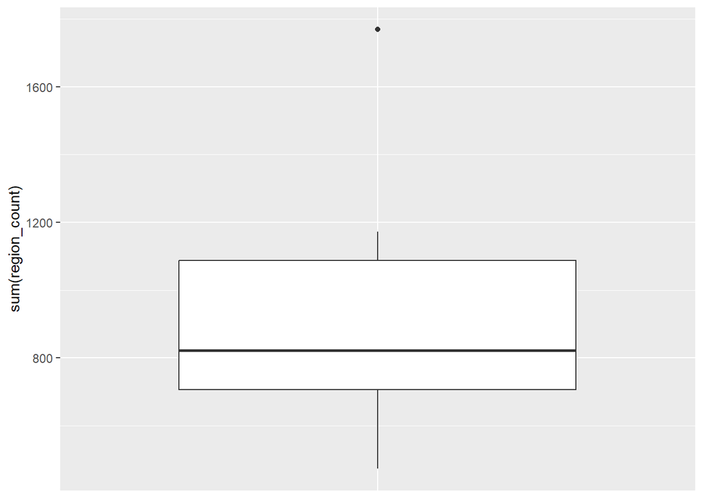

There is an outlier in session 4 which could lead to problems if used in training data.

**Figure 2 and 3**

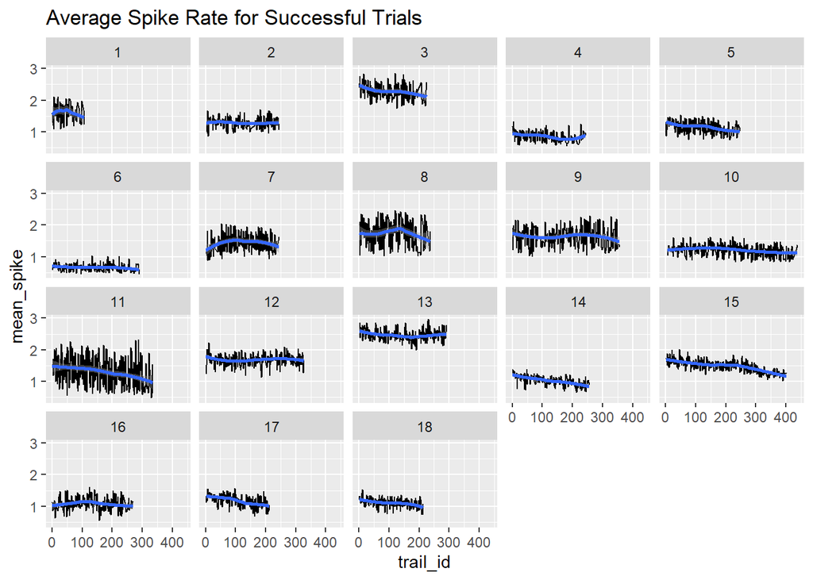

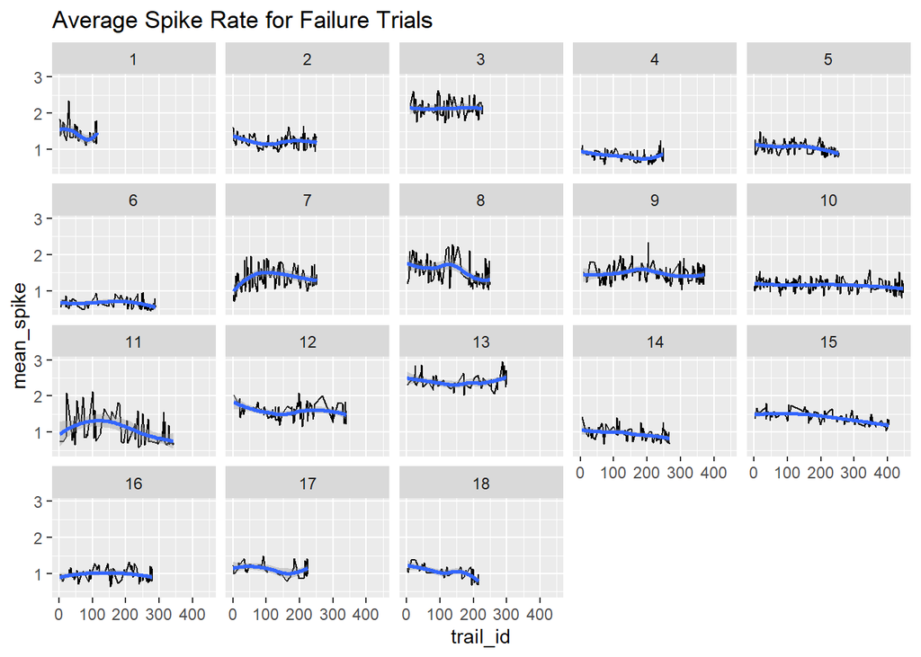

Both success and fail trials follow the same pattern and have no distinct features.

**Figure 4 and 5**

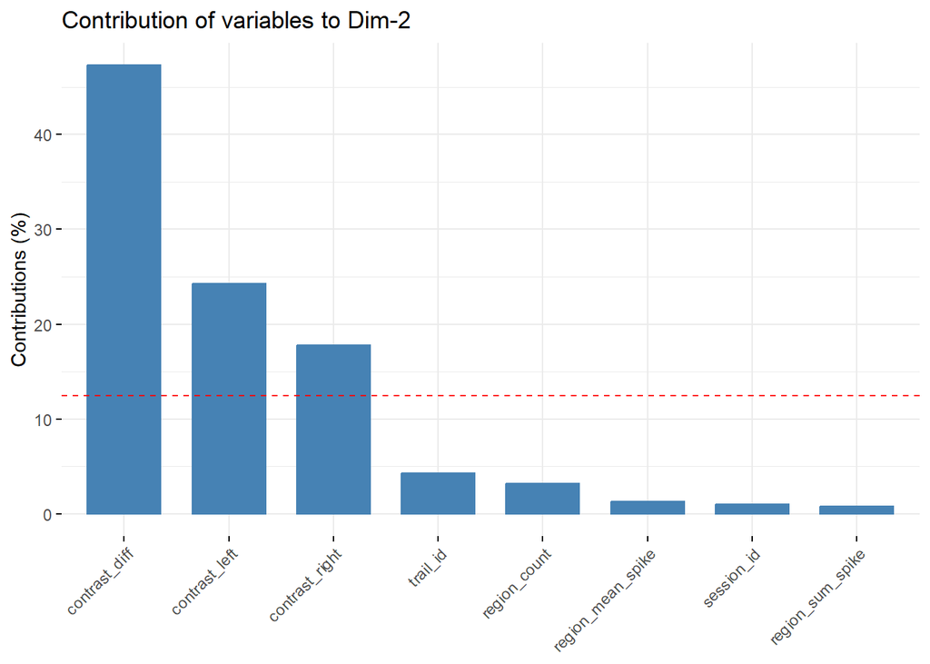

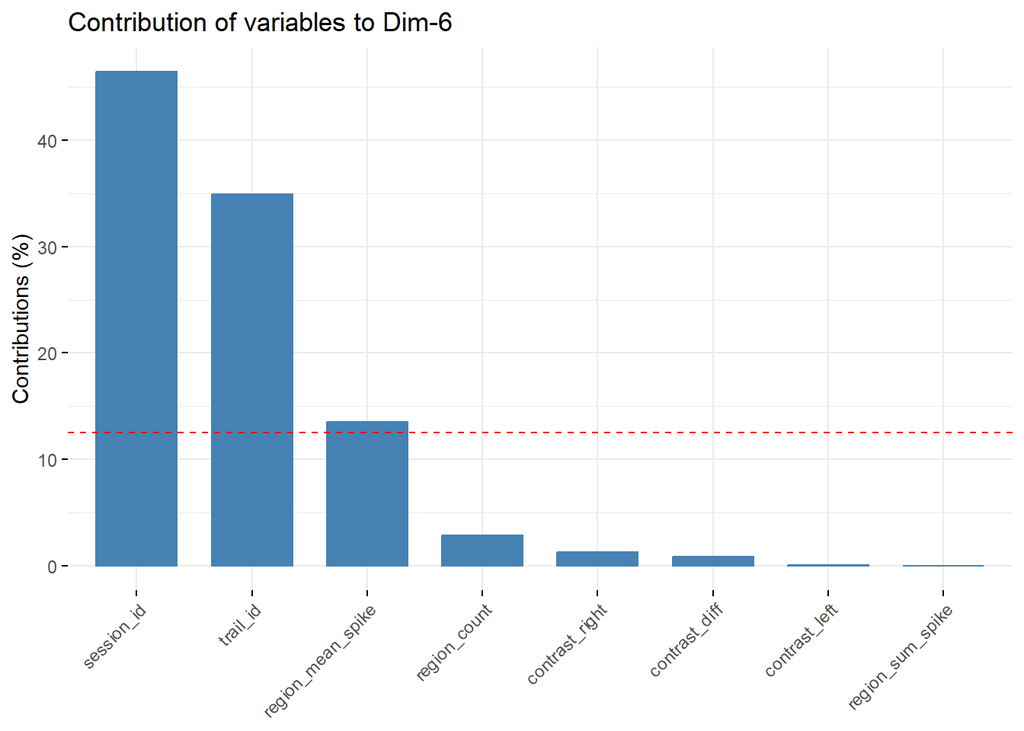

# References

- Github link: https://github.com/annalsi/STA141A-Project.git
- Spatiotemporal Spike Coding on Behavior: https://www.ncbi.nlm.nih.gov/pmc/articles/PMC4534466/
- Using RMarkdown: https://bookdown.org/yihui/rmarkdown/html-document.html
- Understanding PCA:
  - https://hbctraining.github.io/DGE_workshop/lessons/principal_component_analysis.html#:~:text=These%20axes%20that%20represent%20the,which%20we%20could%20have%20variation.
  - https://www.youtube.com/watch?v=3QwZ2GgHSLE I heavily referenced the TA’s Project Demo 1 and Demo 2 along with one of the Consulation Sessions.
- Chat GPT Convo User how to plot roc curve for an xgboost model and logistic regression model in r

ChatGPT In R, you can also plot ROC curves for models like XGBoost and logistic regression. You can use libraries like pROC for computing ROC curve metrics and ggplot2 for plotting. Here’s a step-by-step guide to achieve this:

Install Required Packages: First, if you haven’t already, you need to install the necessary packages pROC and ggplot2. R Copy code install.packages(“pROC”) install.packages(“ggplot2”) Load Required Libraries: Load the required libraries into your R environment. R Copy code library(pROC) library(ggplot2) Train the Models: Train both the XGBoost and logistic regression models using your dataset.

Predict Probabilities: Generate predicted probabilities for both models on a holdout dataset.

Compute ROC Curve Metrics: Use the roc function from the pROC package to compute the ROC curve metrics for both models.

Plot ROC Curve: Finally, use ggplot2 to plot the ROC curves for both models.

Here’s a code example:

R Copy code Assume you have already trained models and have test data Here’s an example with random data for illustration purposes

Generate random data set.seed(123) X <- matrix(rnorm(1000*20), ncol=20) y <- rbinom(1000, 1, 0.5)

Split data into train and test sets train_indices <- sample(1:nrow(X), 0.8*nrow(X)) test_indices <- setdiff(1:nrow(X), train_indices) X_train <- X[train_indices,] y_train <- y[train_indices] X_test <- X[test_indices,] y_test <- y[test_indices]

Train logistic regression model log_reg_model <- glm(y_train ~ ., data=data.frame(cbind(y_train, X_train)), family=binomial)

Train XGBoost model (assuming you have installed the xgboost package) install.packages(“xgboost”) library(xgboost) xgb_model <- xgboost(data = X_train, label = y_train, nrounds = 10, verbose = 0)

Predict probabilities for logistic regression y_pred_proba_lr <- predict(log_reg_model, newdata=data.frame(X_test), type=“response”)

Predict probabilities for XGBoost y_pred_proba_xgb <- predict(xgb_model, newdata = as.matrix(X_test))

Compute ROC curve metrics roc_lr <- roc(y_test, y_pred_proba_lr) roc_xgb <- roc(y_test, y_pred_proba_xgb)

Plot ROC curve plot_roc <- ggroc(list(Logistic_Regression = roc_lr, XGBoost = roc_xgb)) + geom_abline(color=“black”, linetype=“dashed”) + labs(title = “ROC Curve”, x = “False Positive Rate”, y = “True Positive Rate”) + theme_minimal()

print(plot_roc)